# Hispanic Origin Is Not a Race on the Census Form

Two questions about one person on the 2020 census form, and the two boxes people use to answer neither

Democracy’s Data

Last updated September 13, 2026 at 6:12p EDT

The census, people say, tells us what race Americans are. On the 2020 form, question 8 asked whether the person was of Hispanic, Latino or Spanish origin. Question 9 asked what the person’s race was. Between them the Bureau printed a note telling respondents to answer both, and explaining why:

> For this census, Hispanic origins are not races.

That sentence is a decision, made by the federal government, about the relationship between two things people are routinely asked to be one thing about. So what does the census actually measure when it measures race? And what happens when the form’s categories and people’s self-understanding pull apart? Both questions can be answered from the record, because the form that separates race from origin also publishes the two answers together.

## The test

The data is the [2020 Census Redistricting Data (P.L. 94-171) Summary File](https://www2.census.gov/programs-surveys/decennial/2020/data/01-Redistricting_File--PL_94-171/), the counts certified as of 1 April 2020, read here for every county in the United States. A 1975 statute obliges the Bureau to hand this file to every state within a year of Census Day so that legislatures can draw districts from it.[^1] The form’s seven questions, and how one of them becomes most of the published file, are the subject of the decennial chapter.

It is the right file for two reasons. First, it is the operative one. Every legal claim about racial fairness in American elections is stated in its categories. A vote-dilution claim under §2 of the Voting Rights Act, the claim that a district map spreads a minority group’s voters so thinly that they can elect no one, turns on whether the group could form a majority in a district, a number computed from this file.[^2] Language-assistance coverage under §203, which obliges some counties to print ballots in a second language, is decided in the same terms.[^3] If the categories fit people badly, the misfit does not stay in the data; it propagates into the districts, the lawsuits and the money.

Second, the file reports race *crossed with* Hispanic origin, so it can be used to interrogate its own categories. The American Community Survey asks the same two questions in more detail, but it uses the same boxes, so it inherits the misfit rather than measuring it.

The boxes themselves are not the Bureau’s. They come from the **Office of Management and Budget**, a White House office whose Statistical Policy Directive No. 15 binds every federal agency. The version governing 2020, written in 1997,[^4] set five minimum race categories and two ethnicity categories, required that ethnicity be asked first as a separate question, and allowed more than one race. It also said what the categories are not: socio-political constructs, in its own words, not scientific or anthropological ones.

The same text defined White as “a person having origins in any of the original peoples of Europe, the Middle East or North Africa”. A respondent whose family came from Lebanon or Iran had no other place to go. In March 2024 the directive was rewritten again — a single combined question, a new Middle Eastern or North African category, compliance by 2029.[^5]

## The data

Two tables come out of this chapter, and only the first is data to work with. Sizes are rows by columns, read off the files.

[output not shown]

The file has six tables, and this brief reads three of them, named as the Bureau names them: P1 (race), P2 (Hispanic origin by race) and P5 (group quarters, the people counted in prisons, dormitories, nursing homes and the like). The other three repeat P1 and P2 for people 18 and over, and count housing units. The rows here are counties. The Bureau publishes the same tables for every census tract and block, the neighbourhood-sized and block-sized areas that districts are actually drawn from, and those are left aside. Each county is identified by its FIPS code, the five-digit number the federal government assigns every county (`01001` is Autauga County, Alabama). It is kept as text rather than as a number so that the leading zero survives: a code that has quietly become 1,001 no longer matches the same county in any other table. County names come from the Census Gazetteer, the Bureau’s list of places and their codes, matched on that code.

| Item | Value |
| --- | --- |
| Source | 2020 Census Redistricting Data (P.L. 94-171) Summary File |
| Reference date | 1 April 2020 |
| Counties | 3,143 |
| States | 50 and the District of Columbia |
| People covered | 331,449,281 |
| Share of the U.S. population | 100% – every resident of the 50 states and DC |
| Tables kept | P1 (race), P2 (Hispanic origin by race), P5 (group quarters) |

One clean row per county, 3,143 of them: every county and county equivalent (Louisiana’s parishes, Alaska’s boroughs, Virginia’s independent cities) in the fifty states and the District of Columbia. The variables, by name: `total`; the six race-alone counts (`white`, `black`, `aian`, `asian`, `nhpi`, `other_race`) plus `two_or_more`; and the origin pair `hispanic` and `not_hispanic`. An `nh_` version of every race column counts only non-Hispanic respondents, and the group-quarters columns run `gq_correctional` through `gq_military`. The rows sum to 331,449,281 people, which is the 2020 resident population of the United States exactly. Every share below is a national one.

Two things to know about the numbers before reading them. The Bureau injected privacy noise: small deliberate adjustments so that no individual’s answers can be reconstructed, exact at the state level, close at the county level.[^6] And the file’s arithmetic was checked before anything was drawn from it:

| Test | Holds | Counties tested |
| --- | --- | --- |
| one race + two or more races = total, in every county | TRUE | 3143 |
| Hispanic + not Hispanic = total, in every county | TRUE | 3143 |

Nothing that follows is a data-quality problem. The count is exact, it breaks apart without error, and the counties roll up to the Bureau’s own published state and national totals to the person. It is the categories that are in question.

> **Before you read on, commit to two numbers.** In the 2020 census, 27,915,715 people answered the race question by choosing “Some Other Race”, and 33,848,943 reported two or more races. The form asked about Hispanic origin separately, one question earlier. **What share of each of those two groups do you think said yes to it?** Write both percentages down before you read on.

## What it says about democracy

Because Hispanic origin is asked separately, a person can be, and millions are, both Hispanic and white. Which means “how white is this state?” is a question with two correct answers.

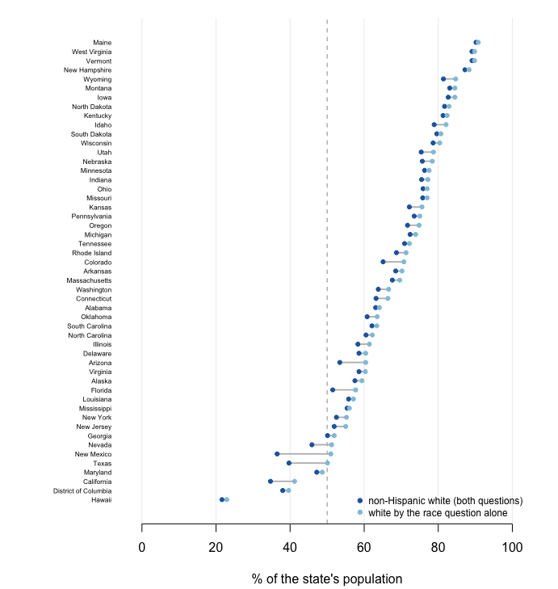

**Figure 1. Two correct answers to “how white is this state?”, in all fifty states and DC.** Each state appears once with two readings joined by a rule: the share answering the race question “white”, and the share who are white *and* not Hispanic. The distance between the dots is the point of the figure: it is the people who are both, and it is why the form is a dumbbell rather than a bar. The dashed line is 50%, and three states have one reading on each side of it. States are ordered here by the race-question reading; in the HTML edition the buttons above the figure reorder them by the size of the gap, which is a different argument, or alphabetically, which is none.

**New Mexico is 51.0% white by the race question and 36.5% white once the origin question is counted.** By one measure it is a majority-white state; by the other it is not close. Both numbers are correct, they answer different questions, and almost nobody reporting a figure like this says which one they used.

New Mexico is the widest case but not a lonely one. Three states — New Mexico, Texas, Nevada — are majority white by the race question and not majority white once the origin question is counted, so the choice of definition decides whether they get described as majority-minority, the usual label for a state where non-Hispanic whites are no longer a majority, at all. Across all 51 states the gap tracks the Hispanic share almost mechanically. The correlation, a measure of how closely two quantities move together in which 1 means perfect lockstep and 0 means no relationship at all, is 0.938: 14.5 points in New Mexico, 0.6 in Mississippi, where few people are both.

So far this is an accounting consequence of asking two questions. It becomes something else in the people who answered the race question by rejecting every box on it. 15.0% of New Mexicans and 13.6% of Texans chose “Some Other Race” — 8.4% of the country — and the file says who they are. It says so by subtraction: P1 counts everyone who chose that box, 27,915,715 people; P2 counts how many of them were not Hispanic, 1,689,833; the difference, 26,225,882, is everyone who was.

| Group | People | Share |
| --- | --- | --- |
| Chose ‘Some Other Race’ | 27,915,715 |  |
| of whom Hispanic | 26,225,882 | 93.9% |
| of whom not Hispanic | 1,689,833 | 6.1% |

**93.9% of the people who rejected every race box are Hispanic.** The leftover category on the race question is, in practice, an ethnicity box. The form asks a question a large minority of respondents do not think is well posed, then records their refusal as though it were an answer.

That would be a contained problem if it were the only such box. The second unusual column is `two_or_more`, normally read as a story about mixed-race families, with Hawaii as the obvious place to look. Most readers’ written-down guess for it is in the teens or twenties.

| Group | People | Share |
| --- | --- | --- |
| Reported two or more races | 33,848,943 |  |
| of whom Hispanic | 20,299,960 | 60.0% |
| of whom not Hispanic | 13,548,983 | 40.0% |

**60.0% of everyone in the country reporting two or more races is Hispanic.** Put every race answer beside the origin answer and both hatches show at once:

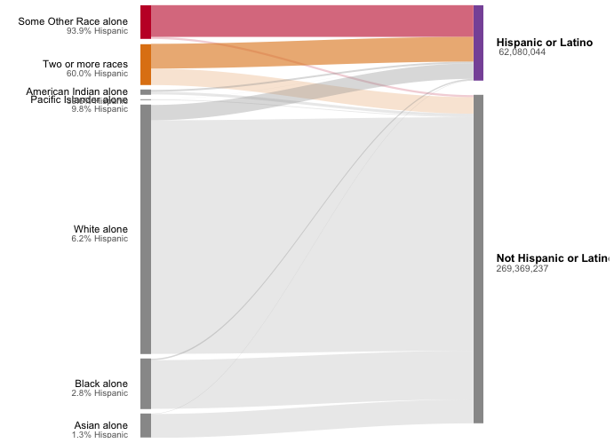

**Figure 2. Every race answer in the 2020 census, split by the answer to the separate origin question.** All 331,449,281 people counted in the fifty states and DC. Bands are ordered by how Hispanic each race answer turned out to be. The two at the top are the two leftover categories: “Some Other Race alone” at 93.9% Hispanic and “Two or more races” at 60.0%. The next answer down is 39.6%, and everything below it behaves nothing like the top two. In the HTML edition, hovering a ribbon gives both of the percentages a cell of a cross-tabulation has: the share of that race answer, and the share of that origin answer.

Hover any ribbon for its two counts, or either end bar for the totals.

The counties say the same thing more sharply. **Nine of the ten most multiracial counties in the country are in Texas**, strung along the Rio Grande; the tenth is Miami-Dade. Every one of them is between 68.7% and 97.7% Hispanic. Hawaii’s most multiracial county, Hawaii County at 29.5%, ranks 25th of 3,143 and does not make the list.

| County | State | Population | % two or more races | % Hispanic |
| --- | --- | --- | --- | --- |
| Starr County | Texas | 65,920 | 47.1 | 97.7 |
| Brooks County | Texas | 7,076 | 46.8 | 88.2 |
| Zapata County | Texas | 13,889 | 45.5 | 93.6 |
| Maverick County | Texas | 57,887 | 43.2 | 94.9 |
| Miami-Dade County | Florida | 2,701,767 | 41.9 | 68.7 |
| Hidalgo County | Texas | 870,781 | 40.6 | 91.9 |
| Cameron County | Texas | 421,017 | 40.4 | 89.5 |
| Webb County | Texas | 267,114 | 40.2 | 95.2 |
| Presidio County | Texas | 6,131 | 39.9 | 81.4 |
| Jim Hogg County | Texas | 4,838 | 36.7 | 88.5 |

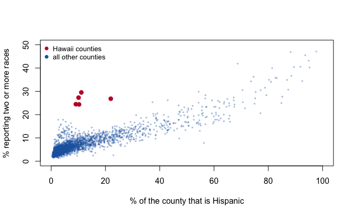

**Figure 3. The multiracial share of a county is largely a function of its Hispanic share.** One dot per county, all 3,143 of them; a scatter, because the claim is a relationship between two shares. The correlation is 0.890. Hawaii’s five counties are picked out because Hawaii is where most people locate multiracial America. They do sit high — 25.3% of the state reports two or more races, and its counties rank between 25th and 49th of 3,143 — but they sit high while barely Hispanic at all, which puts them off the trend rather than at the top of it. They are the exception that a national scatter can show and a six-state one could not.

So the obvious reading is wrong twice over. “Two or more races” is not primarily mixed-race families, and it is not primarily Hawaii. **It is the second escape hatch from the same badly-posed question, used by the same population.** The mechanism is on the form itself. The 2020 questionnaire added write-in lines under the race boxes, and Hispanic respondents who had previously ticked “Some Other Race” alone often wrote origins the Bureau coded as two races. The multiracial count on that border jumped accordingly.[^7]

That is the finding about democracy, and it is worth stating as a rule. **A trend line that crosses a category rewrite partly measures the rewrite.** The 2010-to-2020 rise in multiracial America compares instruments as much as people. The same rule now points forward: the 2024 revision merges race and Hispanic origin into one question by 2029. That change will end the two-answers problem in Figure 1 and make Figures 2 and 3 impossible to extend.

The categories these charts measure are federal policy, revised in 1997 and 2024. Every downstream series is stated in the categories as they stood that decade: districts, §2 claims, funding formulas. The population the 2020 form fit worst is precisely the population those protections most concern.

## What this brief cannot tell you

**A count is not a rate.** Every share above is of the resident population as enumerated, so places with large group-quarters populations — a prison, a campus, a base — carry people counted where the facility is rather than where they live. The `gq_` columns are in the file so that this can be checked rather than assumed.

**What people meant is not in the file.** The write-in text behind “Some Other Race”, where respondents said in their own words what the boxes could not hold, is coded into categories before publication and never released. This brief can show that a hatch was used; it cannot show what was written in it.

**The noise is unquantified.** The privacy adjustments were applied before release and the file carries no column saying by how much. These are counties; the blocks that districts are actually built from are smaller by orders of magnitude, and that is where the noise bites hardest.[^8]

**Decades do not compare.** The 2020 form added write-in areas and examples the 2010 form lacked, and the coding changed with them, so a 2010-to-2020 change in these columns is not a change in people alone.

**Residents, not citizens.** The file counts everyone living in a county, which is what apportionment uses; it says nothing about citizenship.

**Counties, not districts.** Every number here is a county, and counties are not the units districts are built from. The relationships hold across 3,143 counties; whether they hold across blocks is a different question, and the privacy noise is worse there.

## What you should have learned

- Race and Hispanic origin are two separate questions by federal rule, so “how white is New Mexico?” has two correct answers: 51.0% and 36.5%. In three states the two answers fall on opposite sides of 50%.
- The race question has two leftover boxes, and one population uses both: nationally 93.9% of “Some Other Race” and 60.0% of “two or more races” respondents are Hispanic.
- Multiracial geography follows the seam, not Hawaii: the correlation between a county’s Hispanic share and its multiracial share is 0.890 across all 3,143 counties, and nine of the ten most multiracial counties are on the Texas border.
- The categories are set by the Office of Management and Budget, rewritten in 1997 and 2024, so a trend crossing a rewrite partly measures the rewrite.
- The counts themselves are exact and internally consistent: both decompositions hold in all 3,143 counties, and the counties sum to the published national figure of 331,449,281 to the person — which is how a file can be arithmetically perfect and still measure its own categories’ misfit.

## Extensions

None of these is answered above, and every one can be answered by sorting or grouping in a spreadsheet.

- `pl94171_counties.csv` carries both `white` and `nh_white`. Take the difference for every county, divide by `total`, and sort. Where does the choice between the two definitions change the answer most?
- `other_race` and `two_or_more` are the boxes people reach for when none of the offered ones fit. Compute their combined share of `total`, county by county. Which places does the form fit worst?
- `hispanic` and `not_hispanic` should add to `total` in every row. Check it, then explain to somebody who has not read this brief why Hispanic origin is missing from the race columns.
- `gq_correctional` counts people in prison, counted where the facility is. Divide it by `total` and sort. What would the top counties’ shares do to a district drawn from this file?

Two stretch ideas, beyond the spreadsheet. Sort the file to Wayne County, Michigan and its neighbours, where the Middle Eastern and North African population is largest, and ask whether the White column behaves like a box that fits — it is the population the 2024 revision creates a category for. Or pull the 2010 P.L. 94-171 file and compare `two_or_more` county by county, to put a number on how much of the multiracial rise is the instrument rather than the people.

## Sources

**Data**

- U.S. Census Bureau, *2020 Census Redistricting Data (P.L. 94-171) Summary File*, tables P1, P2 and P5, for every county in the fifty states and the District of Columbia. Collected by the Bureau in the 2020 count and published two ways: as one national dataset, `2020/dec/pl` (https://api.census.gov/data/2020/dec/pl), which needs a free key to download, and as one archive per state at https://www2.census.gov/programs-surveys/decennial/2020/data/01-Redistricting_File--PL_94-171/; the numbers here are checked against both. County names come from the Census Gazetteer (https://www.census.gov/geographies/reference-files/time-series/geo/gazetteer-files.html), except Connecticut’s, which the Gazetteer now carries as nine planning regions against this file’s eight counties — two vintages of a boundary, each correct on its own date.
- U.S. Census Bureau, *2020 Census Questionnaire*. The two questions at the head of this brief are its questions 8 and 9, and the sentence between them is the note the Bureau printed to explain why both had to be answered. https://www2.census.gov/programs-surveys/decennial/2020/technical-documentation/questionnaires-and-instructions/questionnaires/2020-informational-questionnaire.pdf

**Literature and law**

- Office of Management and Budget (1997). “Revisions to the Standards for the Classification of Federal Data on Race and Ethnicity.” Statistical Policy Directive No. 15, *Federal Register* 62: 58782 (30 October 1997) — the standard governing the 2020 census. https://www.govinfo.gov/content/pkg/FR-1997-10-30/pdf/97-28653.pdf
- Office of Management and Budget (2024). “Revisions to OMB’s Statistical Policy Directive No. 15.” *Federal Register* 89: 22182 (29 March 2024) — the combined question and the Middle Eastern or North African category. https://www.federalregister.gov/documents/2024/03/29/2024-06469/revisions-to-ombs-statistical-policy-directive-no-15-standards-for-maintaining-collecting-and-presenting-federal-data-on-race-and-ethnicity
- Voting Rights Act § 2, 52 U.S.C. § 10301, and § 203, 52 U.S.C. § 10503 — the enforcement the race and Hispanic-origin questions exist to serve. https://www.law.cornell.edu/uscode/text/52/10301 and https://www.law.cornell.edu/uscode/text/52/10503
- Nobles, M. (2000). *Shades of Citizenship: Race and the Census in Modern Politics.* Stanford: Stanford University Press.
- Prewitt, K. (2013). *What Is Your Race? The Census and Our Flawed Efforts to Classify Americans.* Princeton: Princeton University Press.
- Kenny, C. T., Kuriwaki, S., McCartan, C., Rosenman, E. T. R., Simko, T. and Imai, K. (2021). “The Use of Differential Privacy for Census Data and Its Impact on Redistricting: The Case of the 2020 U.S. Census.” *Science Advances* 7(41): eabk3283. https://pmc.ncbi.nlm.nih.gov/articles/PMC8500496/
- *Alabama v. U.S. Department of Commerce*, 546 F. Supp. 3d 1057 (M.D. Ala. 2021) — Alabama’s challenge to the privacy noise, dismissed.

**The data itself**

Both tables are described in The data at the top of this brief. They are plain CSV, they open in a spreadsheet, and they are yours to take further: `pl94171_counties.csv`, which every figure above is drawn from, and `legacy_six_states.csv`, which the build checks it against.

Rebuild this data yourself, with an AI assistant

```
I want to rebuild a public dataset from its original source, without any
starting files. Please do the following and show your work.

THE SOURCE. U.S. Census Bureau, 2020 Census Redistricting Data
(P.L. 94-171) Summary File -- the file the Bureau is required by law
to hand every state so it can draw districts. It is published two
ways, and part of this exercise is choosing between them.

The Census data API serves it as the dataset 2020/dec/pl:
https://api.census.gov/data/2020/dec/pl
A free key is required (https://api.census.gov/data/key_signup.html);
an unkeyed request redirects to a "missing key" page. The whole
country arrives in one request of about a quarter of a megabyte, as
JSON: an array of arrays with the header row first. Ask for
&for=county:* to get every county, and note that the NAME field
carries a comma ("Autauga County, Alabama"), so split it carefully.

The same file is also published in legacy format, one zip per state,
under
https://www2.census.gov/programs-surveys/decennial/2020/data/01-Redistricting_File--PL_94-171/
No key is needed for those, but there are fifty-one of them and about
1.3 GB to download, and the Bureau publishes no national archive.
Each zip holds four pipe-delimited files with no headers: a geographic
header, one row per geographic unit, and three data segments that join
to it on the LOGRECNO column. Counties are summary level 050. In the
first segment, Table P1 (race) starts at field 6 and Table P2
(Hispanic or Latino origin by race) at field 77; in the third segment,
Table P5 (group quarters) starts at field 6.

Read every code as text -- FIPS codes lose their leading zeros the
moment they become numbers.

WHAT TO BUILD.
1. One county table covering all fifty states and the District of
   Columbia: total population, the six race-alone counts, two or more
   races, the Hispanic and non-Hispanic breakdown of each, and the
   group-quarters counts (correctional, college, military, nursing).
   Leave out Puerto Rico, which ships in the same dataset but whose
   municipios are not counties of a state.
2. If you use the API, satisfy yourself that it really is the same
   file: pull one state's legacy archive as well and compare every
   cell for that state's counties. Do not assume two deliveries of a
   file agree because they are supposed to.

CHECK YOUR WORK. The copies this book used were downloaded in September
2026. If your rebuild matches them, you should find:
- 3,143 county rows across 50 states and DC
- the county totals summing to 331,449,281, the published 2020
  resident population, exactly -- the privacy noise in this file is
  applied so as to leave state and national totals untouched
- Honolulu County, Hawaii: 1,016,508 people, of whom 436,853 are
  Asian alone
- Connecticut with eight counties, not nine planning regions: the
  2020 tabulation predates the change, so a current county name list
  will not join to it cleanly
These are the final legal files of the 2020 census; nothing in them
will change before the 2030 cycle.
```

[^1]: Public Law 94-171, now 13 U.S.C. § 141(c): https://www.law.cornell.edu/uscode/text/13/141.
[^2]: 52 U.S.C. § 10301: https://www.law.cornell.edu/uscode/text/52/10301.
[^3]: 52 U.S.C. § 10503: https://www.law.cornell.edu/uscode/text/52/10503.
[^4]: Office of Management and Budget, “Revisions to the Standards for the Classification of Federal Data on Race and Ethnicity,” *Federal Register* 62 (30 October 1997): 58782, https://www.govinfo.gov/content/pkg/FR-1997-10-30/pdf/97-28653.pdf.
[^5]: Office of Management and Budget, “Revisions to OMB’s Statistical Policy Directive No. 15,” *Federal Register* 89 (29 March 2024): 22182, https://www.federalregister.gov/documents/2024/03/29/2024-06469/revisions-to-ombs-statistical-policy-directive-no-15-standards-for-maintaining-collecting-and-presenting-federal-data-on-race-and-ethnicity.
[^6]: The Bureau’s own account of the method: *Disclosure Avoidance for the 2020 Census: An Introduction* (2021), https://www.census.gov/library/publications/2021/decennial/2020-census-disclosure-avoidance-handbook.html.
[^7]: The Bureau describes the redesign and what it did to the coding in “Improvements to the 2020 Census Race and Hispanic Origin Question Designs, Data Processing, and Coding Procedures” (August 2021): https://www.census.gov/newsroom/blogs/random-samplings/2021/08/improvements-to-2020-census-race-hispanic-origin-question-designs.html.
[^8]: Measured for redistricting by Christopher T. Kenny et al., “The Use of Differential Privacy for Census Data and Its Impact on Redistricting: The Case of the 2020 U.S. Census,” *Science Advances* 7, no. 41 (2021): eabk3283, https://pmc.ncbi.nlm.nih.gov/articles/PMC8500496/.